# Prediction Assignment

Aya Mahfouz

## Executive Summary

This report predicts the class of the person’s activity based on recorded data of his/her motion. Different models have been built and validated with the training data. The most accurate model was then used to predict the possible class for the testing data. Random forests came out as an evident winner in predicting the activity’s class. It should be noted that the `caret` package was too slow in the model building phase so other packages like `randomForest` were considered as well.

## Getting and Cleaning Data

In this phase the data was read and all empty strings and non-numeric values in numeric columns were treated as NA.

```r
training.data <- read.csv("pml-training.csv",na.strings = c('NA','','#DIV/0!'))
testing.data <- read.csv("pml-testing.csv",na.strings = c('NA','','#DIV/0!'))
```

A quick inspection of both the training and testing sets showed that an easy way to get rid of undesired independent columns was to check the unused columns in the testing set and remove them from the training and testing sets. In addition, the first seven columns that contain non-numeric values were removed.

```r
remove.those.columns <- apply(testing.data, 2,
                              function (x) sum(is.na(x)) == nrow(testing.data))

training.data <- training.data[,!remove.those.columns]
training.data <- training.data[,-c(1:7)]

testing.data <- testing.data[,!remove.those.columns]
testing.data <- testing.data[,-c(1:7)]
```

## Model Building

The training data has been divided into testing and validation sets with a ratio of 8:2 rows respectively.

```r
library(caret)
in.train <- createDataPartition(y=training.data$classe,p=0.8,list=FALSE)

training <- training.data[in.train,]
validation <- training.data[-in.train,]
```

Four algorithms were employed:

1. Recursive Partitioning (rpart)
2. Random Forests
3. Linear Discriminant Analysis (LDA)
4. Quadratic Discriminant Analysis (QDA).

`caret`’s implementation of random forests was very slow, so the implementation of the `randomForest` package was employed instead. After building each model using the training set, its accuracy was checked by predicting for the validation set and computing the confusion matrix.

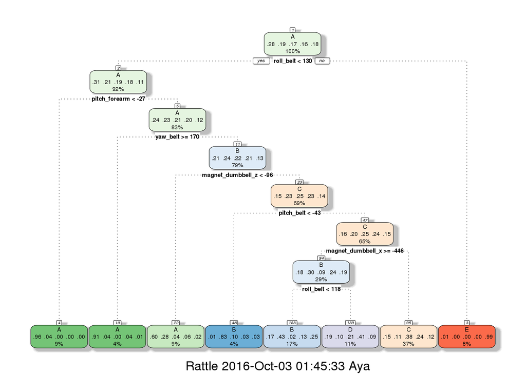

```r
library(utils)
library(kernlab)
library(randomForest)
library(rattle)

set.seed(123)

model.fit.rpart <- train(classe ~ .,method='rpart',data=training)
pred.rpart.val <- predict(model.fit.rpart,newdata=validation,interval="prediction")

fancyRpartPlot(model.fit.rpart$finalModel)
```

```r
confusionMatrix(pred.rpart.val,validation$classe)
```

```
## Confusion Matrix and Statistics
##
##           Reference
## Prediction   A   B   C   D   E
##          A 697 133  21  34  13
##          B 100 456  30 103 175
##          C 229 144 532 321 175
##          D  86  26 101 185  38
##          E   4   0   0   0 320
##
## Overall Statistics
##
##                Accuracy : 0.5582
##                  95% CI : (0.5425, 0.5739)
##     No Information Rate : 0.2845
##     P-Value [Acc > NIR] : < 2.2e-16
##
##                   Kappa : 0.4455
##  Mcnemar's Test P-Value : < 2.2e-16
##
## Statistics by Class:
##
##                      Class: A Class: B Class: C Class: D Class: E
## Sensitivity            0.6246   0.6008   0.7778  0.28771  0.44383
## Specificity            0.9284   0.8710   0.7317  0.92348  0.99875
## Pos Pred Value         0.7762   0.5278   0.3797  0.42431  0.98765
## Neg Pred Value         0.8615   0.9009   0.9397  0.86866  0.88858
## Prevalence             0.2845   0.1935   0.1744  0.16391  0.18379
## Detection Rate         0.1777   0.1162   0.1356  0.04716  0.08157
## Detection Prevalence   0.2289   0.2202   0.3571  0.11114  0.08259
## Balanced Accuracy      0.7765   0.7359   0.7547  0.60559  0.72129
```

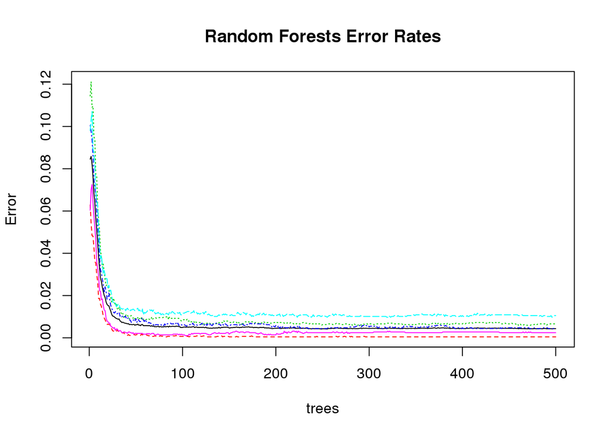

```r
model.fit.rf <- randomForest(classe~., data=training, method="class")
pred.rf.val <- predict(model.fit.rf,newdata=validation,interval="prediction")

plot(model.fit.rf,main="Random Forests Error Rates")
```

```r
confusionMatrix(pred.rf.val,validation$classe)
```

```
## Confusion Matrix and Statistics
##
##           Reference
## Prediction    A    B    C    D    E
##          A 1116    2    0    0    0
##          B    0  757    7    0    0
##          C    0    0  676    5    0
##          D    0    0    1  638    1
##          E    0    0    0    0  720
##
## Overall Statistics
##
##                Accuracy : 0.9959
##                  95% CI : (0.9934, 0.9977)
##     No Information Rate : 0.2845
##     P-Value [Acc > NIR] : < 2.2e-16
##
##                   Kappa : 0.9948
##  Mcnemar's Test P-Value : NA
##
## Statistics by Class:
##
##                      Class: A Class: B Class: C Class: D Class: E
## Sensitivity            1.0000   0.9974   0.9883   0.9922   0.9986
## Specificity            0.9993   0.9978   0.9985   0.9994   1.0000
## Pos Pred Value         0.9982   0.9908   0.9927   0.9969   1.0000
## Neg Pred Value         1.0000   0.9994   0.9975   0.9985   0.9997
## Prevalence             0.2845   0.1935   0.1744   0.1639   0.1838
## Detection Rate         0.2845   0.1930   0.1723   0.1626   0.1835
## Detection Prevalence   0.2850   0.1947   0.1736   0.1631   0.1835
## Balanced Accuracy      0.9996   0.9976   0.9934   0.9958   0.9993
```

```r
model.fit.lda <- train(classe ~ .,data=training,method="lda")
pred.lda.val <- predict(model.fit.lda,newdata=validation,interval="prediction")

confusionMatrix(pred.lda.val,validation$class)
```

```
## Confusion Matrix and Statistics
##
##           Reference
## Prediction   A   B   C   D   E
##          A 925 133  71  34  27
##          B  25 471  70  24 132
##          C  83  82 445  84  77
##          D  80  33  89 475  54
##          E   3  40   9  26 431
##
## Overall Statistics
##
##                Accuracy : 0.7002
##                  95% CI : (0.6856, 0.7145)
##     No Information Rate : 0.2845
##     P-Value [Acc > NIR] : < 2.2e-16
##
##                   Kappa : 0.6203
##  Mcnemar's Test P-Value : < 2.2e-16
##
## Statistics by Class:
##
##                      Class: A Class: B Class: C Class: D Class: E
## Sensitivity            0.8289   0.6206   0.6506   0.7387   0.5978
## Specificity            0.9056   0.9207   0.8994   0.9220   0.9756
## Pos Pred Value         0.7773   0.6524   0.5772   0.6498   0.8468
## Neg Pred Value         0.9301   0.9100   0.9242   0.9474   0.9151
## Prevalence             0.2845   0.1935   0.1744   0.1639   0.1838
## Detection Rate         0.2358   0.1201   0.1134   0.1211   0.1099
## Detection Prevalence   0.3033   0.1840   0.1965   0.1863   0.1297
## Balanced Accuracy      0.8672   0.7706   0.7750   0.8303   0.7867
```

```r
model.fit.qda <- train(classe ~ .,data=training,method="qda")
pred.qda.val <- predict(model.fit.qda,newdata=validation,interval="prediction")
confusionMatrix(pred.qda.val,validation$class)
```

```
## Confusion Matrix and Statistics
##
##           Reference
## Prediction    A    B    C    D    E
##          A 1075   58    1    1    0
##          B   27  607   42    3   28
##          C    7   84  635   96   33
##          D    4    0    2  538   13
##          E    3   10    4    5  647
##
## Overall Statistics
##
##                Accuracy : 0.8927
##                  95% CI : (0.8826, 0.9022)
##     No Information Rate : 0.2845
##     P-Value [Acc > NIR] : < 2.2e-16
##
##                   Kappa : 0.8642
##  Mcnemar's Test P-Value : < 2.2e-16
##
## Statistics by Class:
##
##                      Class: A Class: B Class: C Class: D Class: E
## Sensitivity            0.9633   0.7997   0.9284   0.8367   0.8974
## Specificity            0.9786   0.9684   0.9321   0.9942   0.9931
## Pos Pred Value         0.9471   0.8586   0.7427   0.9659   0.9671
## Neg Pred Value         0.9853   0.9527   0.9840   0.9688   0.9773
## Prevalence             0.2845   0.1935   0.1744   0.1639   0.1838
## Detection Rate         0.2740   0.1547   0.1619   0.1371   0.1649
## Detection Prevalence   0.2893   0.1802   0.2179   0.1420   0.1705
## Balanced Accuracy      0.9709   0.8841   0.9302   0.9155   0.9452
```

Random forests provided the highest accuracy: 99.6% followed by QDA: 89.3% then LDA: 70.0% and in the last place comes recursive partitioning with: 55.8%.

### Comment on Out of Sample Error Rates

I considered the out of sample error rate to be (1 - Accuracy). Random Forests had the lowest out of sample error rate since it employs the bagging technique. Recursive partitioing (classification trees) had the highest out of sample error rate since the relation between the variables cannot be simply explained by a series of binary decisions. LDA had a better rate than recursive partitioning because it tried to establish a linear formula for the independent variables. And QDA’s rate was better than that of LDA since it established a polynomial formula for the aforementioned variables.

## Prediction

Since random forests provided the highest accuracy rate, it was used to predict the quiz answers (and they all happened to be correct).

```r
library(randomForest)
pred.rf <- predict(model.fit.rf,newdata=testing.data,interval="prediction")
pred.rf
```

```
##  1  2  3  4  5  6  7  8  9 10 11 12 13 14 15 16 17 18 19 20
##  B  A  B  A  A  E  D  B  A  A  B  C  B  A  E  E  A  B  B  B
## Levels: A B C D E
```

## References

1. Lecture Notes
2. [CRAN Task View: Machine Learning & Statistical Learning](https://cran.r-project.org/web/views/MachineLearning.html)